# Guía Análisis de Componentes Principales

Métodos de análisis no paramétricos

Dr. José A. Gallardo.

Profesor adjunto de la Pontificia Universidad Católica de Valparaíso  
jose.gallardo@pucv.cl

June 05, 2022

#### Objetivos de aprendizaje

Elaborar análisis de componentes principales con el **software R**.

#### Conceptos importantes

**Análisis de componentes principales**  
Es una herramienta utilizada para realizar análisis exploratorio de datos multivariantes y para construir modelos predictivos.

Permite reducir la dimensionalidad y encontrar patrones en un set de datos mediante el calculo de los “componentes principales”.

Los componentes principales se ordenan por la cantidad de varianza original que describen [Wiki.](https://es.wikipedia.org/wiki/An%C3%A1lisis_de_componentes_principales).

#### Software.

Esta es la versión de R que se usó para crear esta guía.

```r
R.version.string
```

```
## [1] "R version 4.0.3 (2020-10-10)"
```

#### Librerías.

**{stats}**  
This package contains functions for statistical calculations and random number generation.

**{readxl}**  
Read Excel Files.

**{dplyr}**  
Librería para manipular datos.

**{psych}**  
Procedures for Psychological, Psychometric, and Personality Research

**{factoextra}**  
Extract and Visualize the Results of Multivariate Data Analyses.

**{MVN}**  
Multivariate Normality Tests

#### Comandos para realizar los análisis.

**read_excel()**  
Importa datos a R desde archivos excel.

#### EJERCICIOS

Realice los ejercicios de forma colaborativa con uno o dos compañeros.

Elabore un archivo con extensión **.R** en Rstudio o Rstudio.cloud

Habilite los paquetes **stats**, **readxl**, **dplyr**, **ggplot2**, **psych**, **factoextra** y **MVN** usando la función library().

A partir del set de datos **data_PCA.xlsx** parcialmente obtenidos desde el paper de [Rivera y colaboradores, 2019](https://www.sciencedirect.com/science/article/abs/pii/S0025326X19305004?via%3Dihub) que analiza la calidad de agua y la concentración de metales pesados del Humedal el Yali en Chile central realice los siguientes ejercicios.

**Ejercicio 1.** Importar y explorar

1. Importe la hoja 1 set de datos **data_PCA.xlsx** usando la función *read_excel()* de la librería *readxl*. No olvide usar el argumento *Sheet=1*. Explore el set de datos usando las funciones *summary()*. Compruebe que todas las variables,ssin contar Sitio, están expresadas como número. Caso contrario realice los cambios correspondientes con las funciones **as.numeric()**.

```
##     Sitio                 TS             PH                 ALC
##  Length:11          Min.   :19.00   Length:11          Min.   : 140.0
##  Class :character   1st Qu.:22.35   Class :character   1st Qu.: 235.0
##  Mode  :character   Median :22.80   Mode  :character   Median : 460.0
##                     Mean   :23.25                      Mean   : 458.2
##                     3rd Qu.:24.00                      3rd Qu.: 585.0
##                     Max.   :28.00                      Max.   :1050.0
##      CONDUC            TURB             OD              SAL
##  Min.   :  4920   Min.   :10.00   Min.   : 4.400   Min.   :  3000
##  1st Qu.:  8865   1st Qu.:17.50   1st Qu.: 6.000   1st Qu.:  6000
##  Median : 36600   Median :22.00   Median : 6.700   Median : 23000
##  Mean   : 48098   Mean   :24.99   Mean   : 7.155   Mean   : 34091
##  3rd Qu.: 61100   3rd Qu.:34.00   3rd Qu.: 8.400   3rd Qu.: 40000
##  Max.   :183000   Max.   :39.00   Max.   :10.500   Max.   :151000
##     DURECAL          SSED              SS             DBO
##  Min.   :  60   Min.   :0.1000   Min.   :0.008   Min.   :10.00
##  1st Qu.: 110   1st Qu.:0.1000   1st Qu.:0.045   1st Qu.:10.50
##  Median : 500   Median :0.1000   Median :0.220   Median :11.50
##  Mean   : 580   Mean   :0.4364   Mean   :0.292   Mean   :11.50
##  3rd Qu.: 950   3rd Qu.:0.6500   3rd Qu.:0.252   3rd Qu.:12.25
##  Max.   :1560   Max.   :1.5000   Max.   :1.592   Max.   :14.00
##     ACEITES            NORG             NO3             NH4
##  Min.   : 1.000   Min.   :   4.7   Min.   : 3.80   Min.   : 0.90
##  1st Qu.: 4.100   1st Qu.:  55.6   1st Qu.:11.45   1st Qu.: 2.25
##  Median : 6.100   Median : 133.5   Median :14.40   Median : 6.20
##  Mean   : 8.336   Mean   : 360.2   Mean   :19.65   Mean   :16.70
##  3rd Qu.: 8.850   3rd Qu.: 722.5   3rd Qu.:23.60   3rd Qu.:22.35
##  Max.   :33.600   Max.   :1060.0   Max.   :50.00   Max.   :75.50
##       PORG             CLOR             Cu                Pb
##  Min.   :0.0200   Min.   : 1631   Min.   :0.00210   Min.   :0.0275
##  1st Qu.:0.0400   1st Qu.: 2617   1st Qu.:0.02010   1st Qu.:0.1711
##  Median :0.0400   Median :19072   Median :0.02090   Median :0.2548
##  Mean   :0.1527   Mean   :21742   Mean   :0.02741   Mean   :0.2322
##  3rd Qu.:0.0400   3rd Qu.:24427   3rd Qu.:0.03030   3rd Qu.:0.2838
##  Max.   :0.8800   Max.   :90539   Max.   :0.08390   Max.   :0.4167
```

```
## tibble [11 × 20] (S3: tbl_df/tbl/data.frame)
##  $ Sitio  : chr [1:11] "ALB1" "ALB2" "YALI1" "YALI2" ...
##  $ TS     : num [1:11] 22.2 25 21.3 19 23 28 22.6 22.8 22.8 22.5 ...
##  $ PH     : num [1:11] 8.5 8.5 8.4 9.5 8.4 8.9 9.5 9.4 9.5 9.1 ...
##  $ ALC    : num [1:11] 160 460 420 140 620 200 560 610 550 1050 ...
##  $ CONDUC : num [1:11] 65800 65700 56500 56500 4920 ...
##  $ TURB   : num [1:11] 39 39 22 21.9 10 ...
##  $ OD     : num [1:11] 5.6 6.5 4.4 9.4 8.9 6.1 5.9 6.8 6.7 7.9 ...
##  $ SAL    : num [1:11] 37000 37000 43000 43000 3000 151000 5000 7000 5000 21000 ...
##  $ DURECAL: num [1:11] 1560 1240 1200 600 60 700 100 100 120 200 ...
##  $ SSED   : num [1:11] 0.1 0.1 0.1 0.1 0.5 0.8 0.1 0.1 0.1 1.3 ...
##  $ SS     : num [1:11] 0.22 0.236 0.336 0.26 0.038 ...
##  $ DBO    : num [1:11] 10 14 13 10 11.5 13 10 11 11 11.5 ...
##  $ ACEITES: num [1:11] 4.3 1.8 1 4.2 12.3 6.1 4 6.7 6.7 33.6 ...
##  $ NORG   : num [1:11] 133.5 106 88.8 331 4.7 ...
##  $ NO3    : num [1:11] 12.8 13.1 3.8 8.6 10.1 50 16.4 15.8 14.4 30.8 ...
##  $ NH4    : num [1:11] 25.4 19.5 20.2 24.5 0.9 75.5 2.1 2.4 1.8 6.2 ...
##  $ PORG   : num [1:11] 0.04 0.04 0.04 0.04 0.88 0.04 0.48 0.04 0.04 0.02 ...
##  $ CLOR   : num [1:11] 23680 24250 24604 33819 1631 ...
##  $ Cu     : num [1:11] 0.0312 0.0217 0.0201 0.0209 0.0021 0.0201 0.0839 0.0201 0.0146 0.0374 ...
##  $ Pb     : num [1:11] 0.2828 0.2214 0.2548 0.2828 0.0275 ...
```

2. Elabore gráficas de correlaciones no paramétricas de spearman de todas las variables numéricas en grupos de 6 o 7 usando la función **pairs.panels()**.

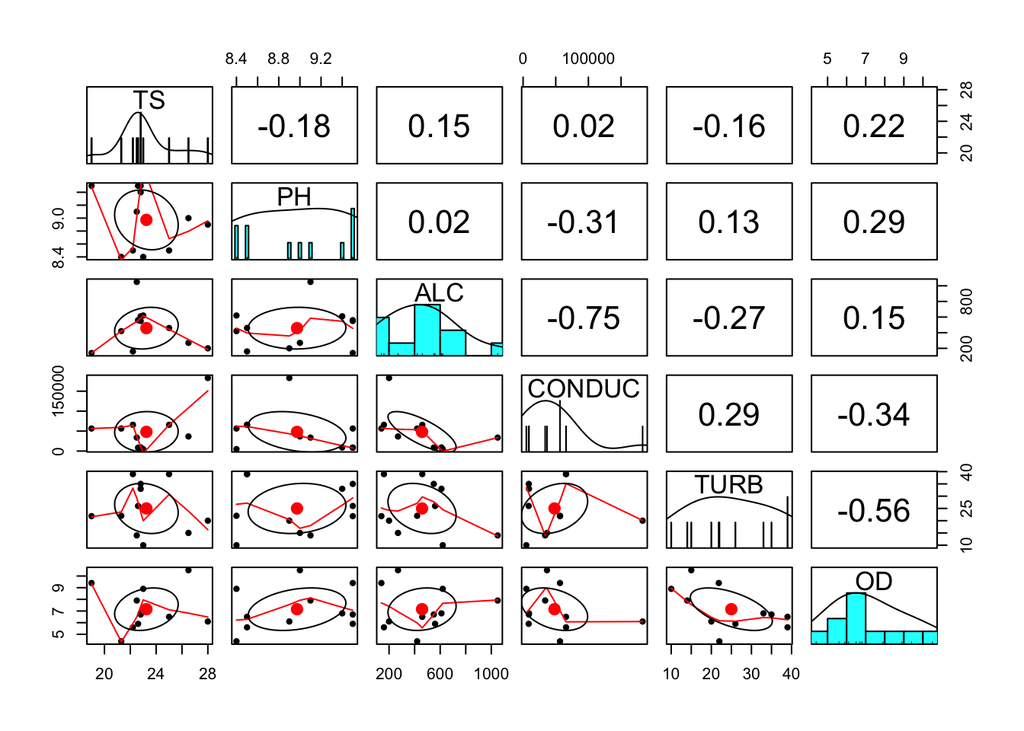

[figure not shown]

[figure not shown]

```r
pairs.panels(Yali[2:7], method = "spearman")
```

¿Qué variables están altamente correlacionadas de forma positiva? ¿Qué variables están altamente correlacionadas de forma negativa? ¿Qué variables no están altamente correlacionadas?

**Ejercicio 2.** Extrae set de datos

1. Elabore un nuevo set de datos llamado **Yali_new** solo con las variables numéricas (columnas 2-20), utilice la columna Sitio para agregar el nombre de las filas con la función **row.names()**. Visualice el set de datos con **head()**.

```r
Yali_new <- as.data.frame(Yali[,2:20])
row.names(Yali_new) <- Yali$Sitio
head(Yali_new)
```

```
##         TS  PH ALC CONDUC     TURB  OD    SAL DURECAL SSED    SS  DBO ACEITES
## ALB1  22.2 8.5 160  65800 39.00000 5.6  37000    1560  0.1 0.220 10.0     4.3
## ALB2  25.0 8.5 460  65700 39.00000 6.5  37000    1240  0.1 0.236 14.0     1.8
## YALI1 21.3 8.4 420  56500 22.00000 4.4  43000    1200  0.1 0.336 13.0     1.0
## YALI2 19.0 9.5 140  56500 21.85714 9.4  43000     600  0.1 0.260 10.0     4.2
## YALI3 23.0 8.4 620   4920 10.00000 8.9   3000      60  0.5 0.038 11.5    12.3
## COL   28.0 8.9 200 183000 20.00000 6.1 151000     700  0.8 1.592 13.0     6.1
##         NORG  NO3  NH4 PORG  CLOR     Cu     Pb
## ALB1   133.5 12.8 25.4 0.04 23680 0.0312 0.2828
## ALB2   106.0 13.1 19.5 0.04 24250 0.0217 0.2214
## YALI1   88.8  3.8 20.2 0.04 24604 0.0201 0.2548
## YALI2  331.0  8.6 24.5 0.04 33819 0.0209 0.2828
## YALI3    4.7 10.1  0.9 0.88  1631 0.0021 0.0275
## COL   1060.0 50.0 75.5 0.04 90539 0.0201 0.4167
```

**Ejercicio 3.** Análisis de Componentes Principales

1. Realice un análisis de componentes principales para el nuevo set de datos **Yali_new** con la función **prcomp**, use los argumento *scale = TRUE* para estandarizar las variables de forma automática. Almacene el ACP en un nuevo objeto denominado **Yalipca**.

```r
Yalipca <- prcomp(Yali_new, scale = TRUE)
```

3. Usando el objeto **Yalipca**, obtenga la varianza explicada por cada CP con la función **get_eigenvalue()** y grafique con la función **fviz_eig()**.

```
##          eigenvalue variance.percent cumulative.variance.percent
## Dim.1  7.369239e+00     3.878547e+01                    38.78547
## Dim.2  3.790602e+00     1.995053e+01                    58.73600
## Dim.3  2.476981e+00     1.303674e+01                    71.77274
## Dim.4  1.544021e+00     8.126424e+00                    79.89917
## Dim.5  1.365529e+00     7.186997e+00                    87.08616
## Dim.6  1.032498e+00     5.434201e+00                    92.52037
## Dim.7  8.733514e-01     4.596586e+00                    97.11695
## Dim.8  3.585748e-01     1.887236e+00                    99.00419
## Dim.9  1.726563e-01     9.087176e-01                    99.91291
## Dim.10 1.654802e-02     8.709486e-02                   100.00000
## Dim.11 7.051766e-32     3.711456e-31                   100.00000
```

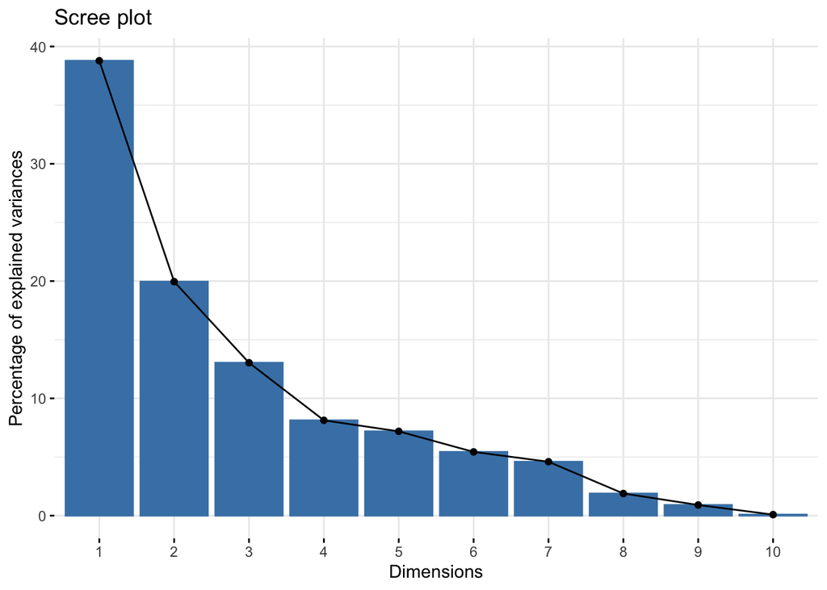

¿Cuántos componentes principales se requieren para explicar al menos un 79% de la variabilidad de los datos? ¿Qué proporción de la variabilidad de los datos son explicadas por los 2 primeros componentes principales?

4. Elabore gráficas para representar la distribución de los sitios **fviz_pca_ind()**, de las variables **fviz_pca_var()** y gráficas Biplot de sitios y variables **fviz_pca_biplot()**

Grafica de sitios ¿Qué sitio está menos relacionado con el resto respecto del CP1? ¿Qué sitios están más relacionados respecto del CP2?

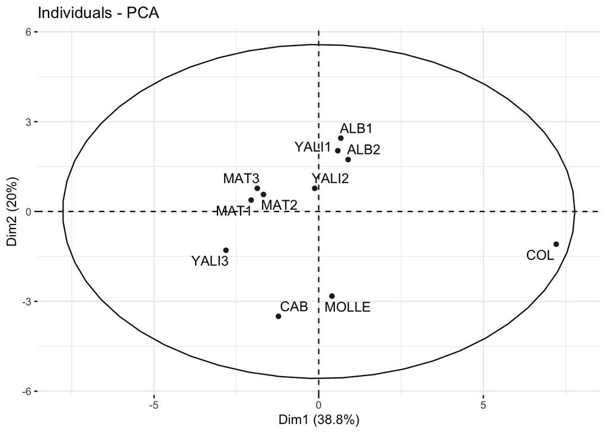

```r
fviz_pca_ind(Yalipca, repel = TRUE, addEllipses=TRUE) # evita que se solape el nombre de los sitios
```

Grafica de variables ¿Qué variables ambientales están altamente correlacionadas de forma positiva? ¿Qué variables ambientales están altamente correlacionadas de forma negativa? ¿Qué variables ambientales no están correlacionadas?

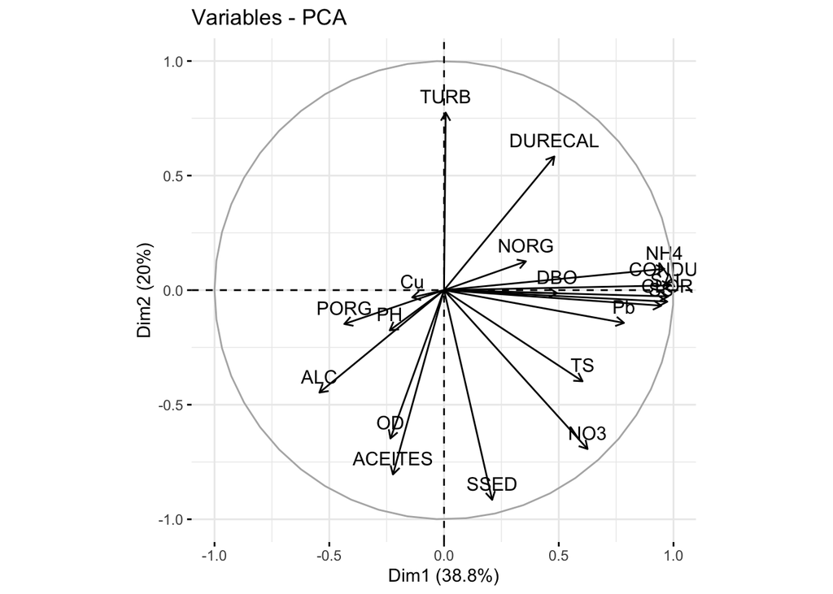

```r
fviz_pca_var(Yalipca)
```

Gráfica bi-plot

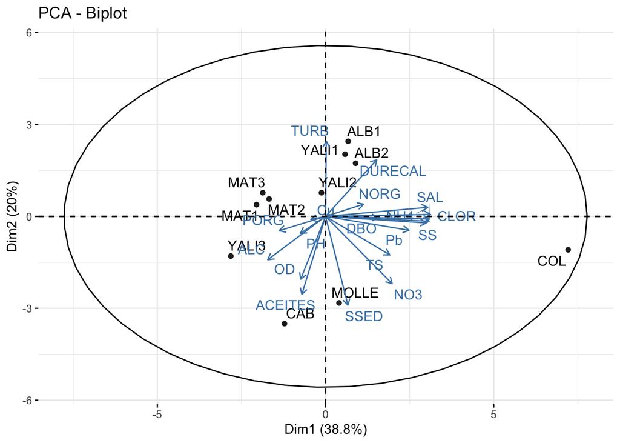